# 02_transform_data

Suguru Otani

2022/7/2

```r
operator_level_entry_exit_merger_CIY <-
  readr::read_csv("../input/operator_level_entry_exit_merger_CIY.csv") %>%
  dplyr::distinct(
    operator,
    state,
    .keep_all = TRUE
    ) %>%
  dplyr::mutate(
    dummy_merged_until_data_period =
      ifelse(
        is.na(dummy_merged_until_data_period) == 1,
        0,
        1
        )
  )
```

[output not shown]

```r
operator_level_entry_exit_merger_HBdata <-
  readr::read_csv("../input/operator_level_entry_exit_merger_HBdata.csv") %>%
  dplyr::distinct(
    operator_name,
    .keep_all = TRUE
    )
```

[output not shown]

```r
HB_data <-
  readRDS(file = "../cleaned/HB_data.rds")
shipdetails_container_data <-
  readRDS(file = "../cleaned/shipdetails_container_data.rds")
merging_firm_list <-
  readRDS(file = "../cleaned/merging_firm_list.rds")
```

# Entry, exit, and mergers

## Operator

### CIY

#### Merger list

| …1 | operator | state | market | start | end | merging_firm | note | dummy_merged_until_data_period | merging_firm_color |
| --- | --- | --- | --- | --- | --- | --- | --- | --- | --- |
| 135 | Moore-McCormack Lines Inc | noncartel_only_in_CIY | Transatlantic | 1965 | 1965 | United States Lines | Merged by United States Lines in 1982 | 1 | United States Lines |
| 78 | Moore-McCormack Lines Inc | cartel | Transatlantic | 1966 | 1970 | United States Lines | Merged by United States Lines in 1982 | 1 | United States Lines |
| 145 | Marasia | noncartel_only_in_CIY | Transatlantic | 1969 | 1990 | NA | Taken over in 1987 | 1 | NA |
| 288 | KSC | noncartel_only_in_CIY | Transpacific | 1971 | 1975 | Hanjin | Merged by Hanjin in 1987 | 1 | Hanjin |
| 4 | OCL | cartel | Asia and Eur | 1972 | 1986 | P&O | Merged by P&O in 1986 | 1 | P&O |
| 293 | Atlanttrafik/Barber Blue Sea | noncartel_only_in_CIY | Transpacific | 1974 | 1990 | Wilhelmsen Lines A/S | Merged by Wilhelmsen Lines A/S since 1990 | 1 | Wilhelmsen Lines A/S |
| 94 | Y-S Line | cartel | Transatlantic | 1974 | 1988 | NLS | Merged as NLS since 1989 | 1 | NLS |
| 13 | Franco-Belgian Services | cartel | Asia and Eur | 1976 | 1990 | Maersk | Merged by Maersk in 1987 | 1 | Maersk |
| 239 | Barber Blue Sea Line | cartel | Transpacific | 1977 | 1990 | Wilhelmsen Lines A/S | Merged by Wilhelmsen Lines A/S since 1990 | 1 | Wilhelmsen Lines A/S |
| 64 | Finland Steamship | noncartel_only_in_CIY | Asia and Eur | 1977 | 1990 | Finnlines | Merged by Finnlines in 1990 | 1 | Finnlines |
| 21 | KSC | cartel | Asia and Eur | 1979 | 1987 | Hanjin | Merged by Hanjin in 1987 | 1 | Hanjin |
| 244 | Japan Line | cartel | Transpacific | 1981 | 1988 | NLS | Merged as NLS since 1989 | 1 | NLS |
| 45 | KSC | noncartel | Asia and Eur | 1988 | 1990 | Hanjin | Merged by Hanjin in 1987 | 1 | Hanjin |

#### Overall Transition

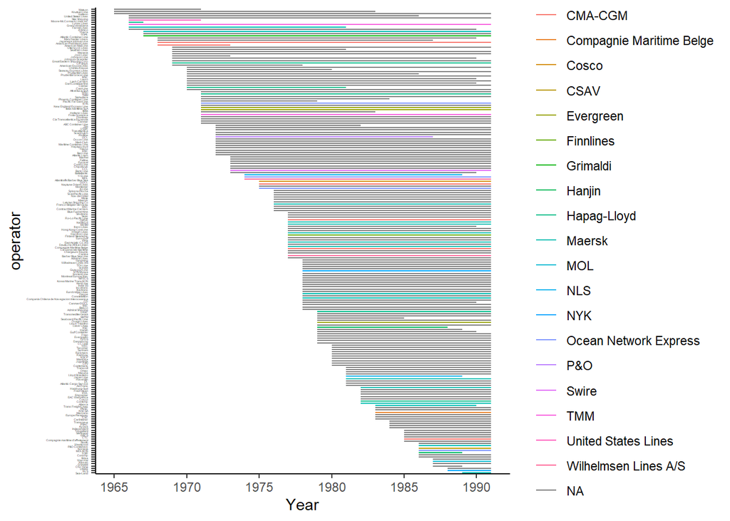

| …1 | operator | state | market | start | end | merging_firm | note | dummy_merged_until_data_period | merging_firm_color |
| --- | --- | --- | --- | --- | --- | --- | --- | --- | --- |
| 281 | Galleon | noncartel_only_in_CIY | Transpacific | 1965 | 1990 | NA | NA | 0 | Galleon |
| 224 | Knutsen Line | cartel | Transpacific | 1965 | 1982 | NA | Ongoing | 0 | Knutsen Line |
| 248 | Matson | noncartel | Transpacific | 1965 | 1970 | NA | Ongoing | 0 | Matson |
| 81 | d’Amico | cartel | Transatlantic | 1966 | 1989 | NA | Ongoing | 0 | d’Amico |
| 79 | Farrell Lines | cartel | Transatlantic | 1966 | 1980 | Maersk | Subsidiary of Maersk since 2005 (Merged by P&O Nedlloyd in 2000) | 0 | Maersk |
| 100 | Grancolombiana | noncartel | Transatlantic | 1966 | 1990 | TMM | Merged by TMM in 1996 | 0 | TMM |
| 77 | Lykes Lines | cartel | Transatlantic | 1966 | 1966 | Hapag-Lloyd | Subsidiary of Hapag-Lloyd since 2005 (Merged by CP Ships in 1997) | 0 | Hapag-Lloyd |
| 78 | Moore-McCormack Lines Inc | cartel | Transatlantic | 1966 | 1970 | United States Lines | Merged by United States Lines in 1982 | 1 | United States Lines |
| 101 | Star Shipping | noncartel | Transatlantic | 1966 | 1990 | NA | Ongoing | 0 | Star Shipping |
| 80 | United States Lines | cartel | Transatlantic | 1966 | 1985 | NA | Bankrupt in 1987 | 0 | United States Lines |
| 84 | Atlantic Container Line | cartel | Transatlantic | 1967 | 1990 | Grimaldi | Merged by Grimaldi in 2001 | 0 | Grimaldi |
| 141 | GSAL | noncartel_only_in_CIY | Transatlantic | 1967 | 1990 | NA | NA | 0 | GSAL |
| 142 | Ybarra | noncartel_only_in_CIY | Transatlantic | 1967 | 1990 | Maersk | Subsidiary of Maersk since 2017(Merged by Hamburg Sud in 2007) | 0 | Maersk |
| 225 | American Mail Line | cartel | Transpacific | 1968 | 1972 | CMA-CGM | Subsidiary of CMA-CGM since 2016 (Subsidiary of NOL since 1998)(Merged by American President Lines in 1973) | 0 | CMA-CGM |
| 227 | American President Lines | cartel | Transpacific | 1968 | 1990 | CMA-CGM | Subsidiary of CMA-CGM since 2016 (Subsidiary of NOL since 1998) | 0 | CMA-CGM |
| 226 | Japanese joint service | cartel | Transpacific | 1968 | 1986 | NA | A Group in Conference | 0 | Japanese joint service |
| 85 | Manchester Liners | cartel | Transatlantic | 1968 | 1989 | NA | Liquidated in 1985, and services were taken over by OOCL | 0 | Manchester Liners |
| 86 | American Export Lines | cartel | Transatlantic | 1969 | 1977 | NA | Bankrupt in 1978 | 0 | American Export Lines |
| 88 | CP Ships | cartel | Transatlantic | 1969 | 1990 | Hapag-Lloyd | Subsidiary of Hapag-Lloyd since 2005 | 0 | Hapag-Lloyd |
| 250 | Great Eastern Shipping Corp | noncartel | Transpacific | 1969 | 1990 | NA | Ongoing | 0 | Great Eastern Shipping Corp |
| 102 | Johnson Line | noncartel | Transatlantic | 1969 | 1972 | NA | Merged as Effjohn in 1990 | 0 | Johnson Line |
| 103 | Johnson-Scanstar | noncartel | Transatlantic | 1969 | 1989 | NA | Operation stopped in 1990 | 0 | Johnson-Scanstar |
| 104 | Joon Liner | noncartel | Transatlantic | 1969 | 1990 | NA | NA | 0 | Joon Liner |
| 145 | Marasia | noncartel_only_in_CIY | Transatlantic | 1969 | 1990 | NA | Taken over in 1987 | 1 | NA |
| 87 | Seatrain Lines | cartel | Transatlantic | 1969 | 1980 | NA | Bankrupt in 1982 | 0 | Seatrain Lines |
| 146 | Uiterwyck Lines | noncartel_only_in_CIY | Transatlantic | 1969 | 1990 | NA | NA | 0 | Uiterwyck Lines |
| 147 | Atkabtuca SpA | noncartel_only_in_CIY | Transatlantic | 1970 | 1990 | NA | NA | 0 | Atkabtuca SpA |
| 105 | Cast Line | noncartel | Transatlantic | 1970 | 1980 | Hapag-Lloyd | Subsidiary of Hapag-Lloyd since 2005 (Merged by CP Ships in 1995) | 0 | Hapag-Lloyd |
| 148 | Ciamar | noncartel_only_in_CIY | Transatlantic | 1970 | 1990 | NA | NA | 0 | Ciamar |
| 91 | Dart Containerline | cartel | Transatlantic | 1970 | 1989 | NA | Services were taken over by OOCL | 0 | Dart Containerline |

[output cut: 178 more lines]

### Shipdetails

[figure not shown]

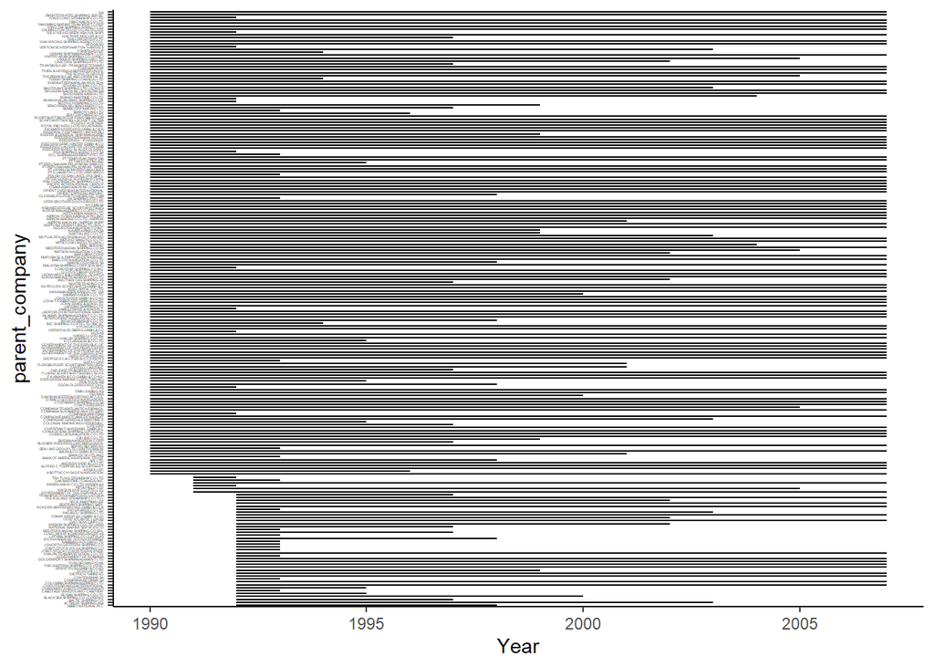

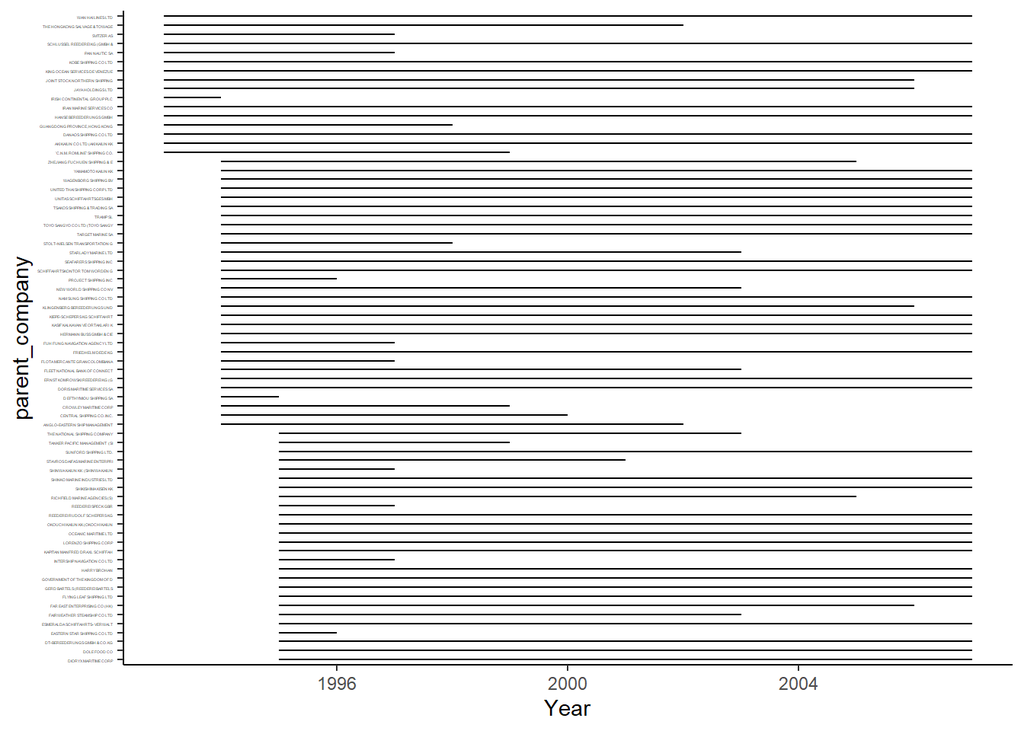

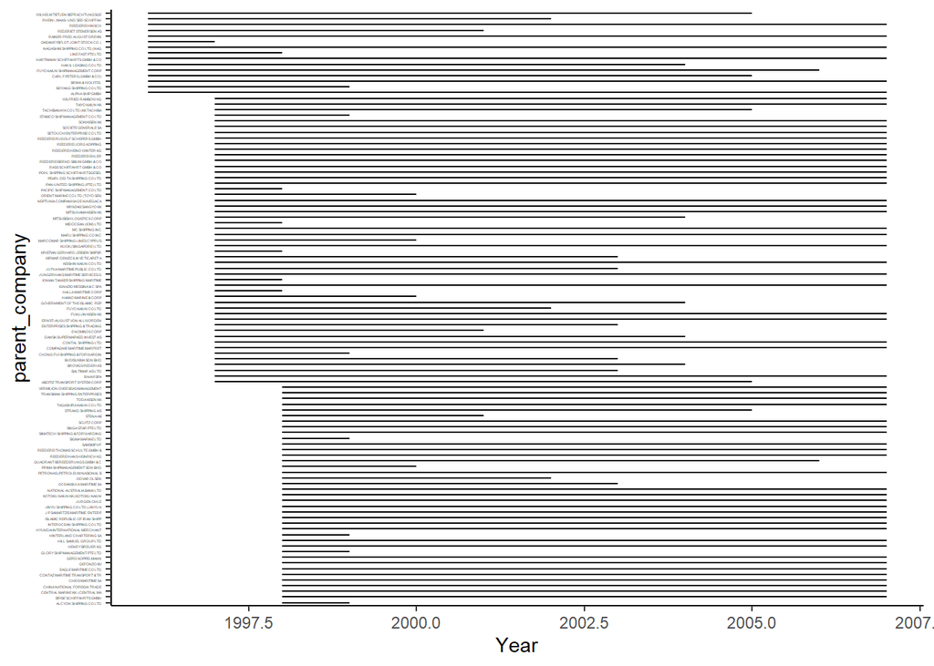

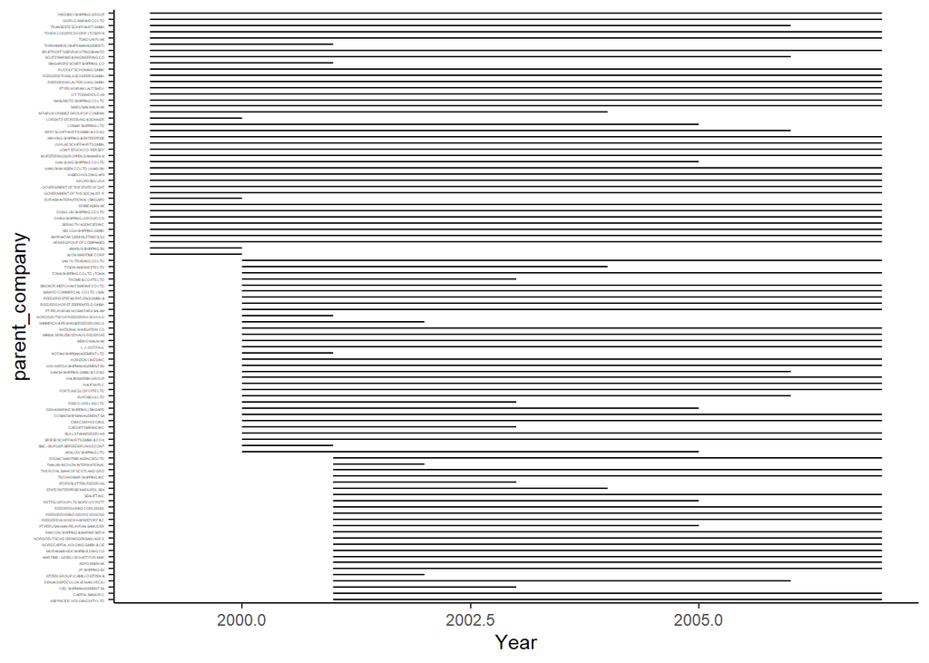

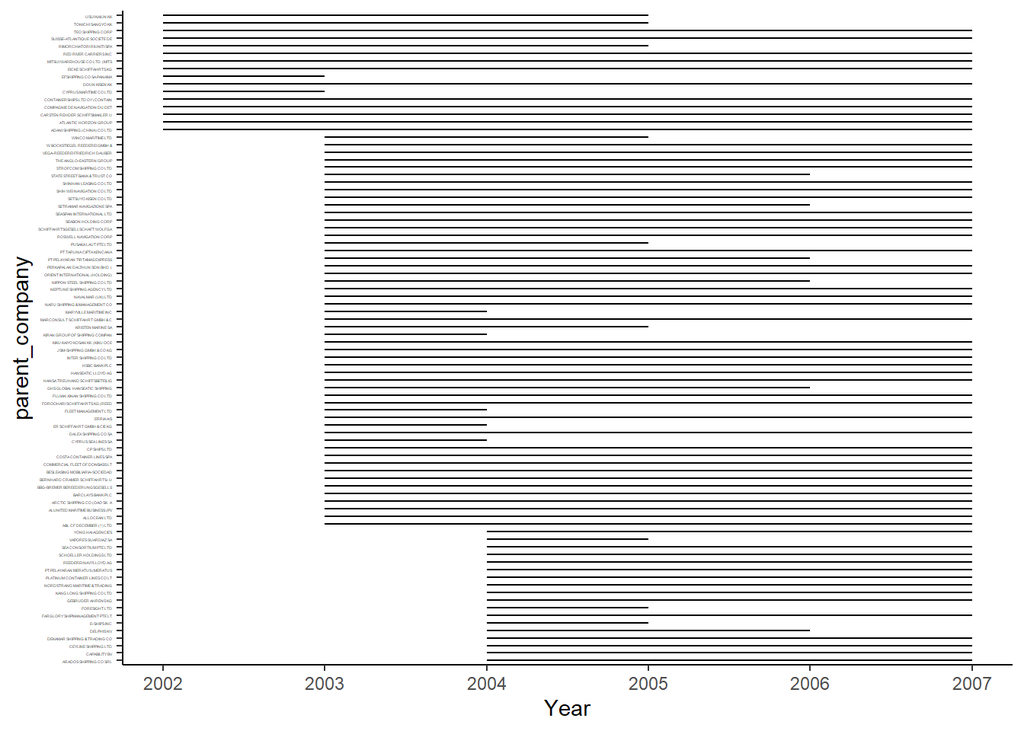

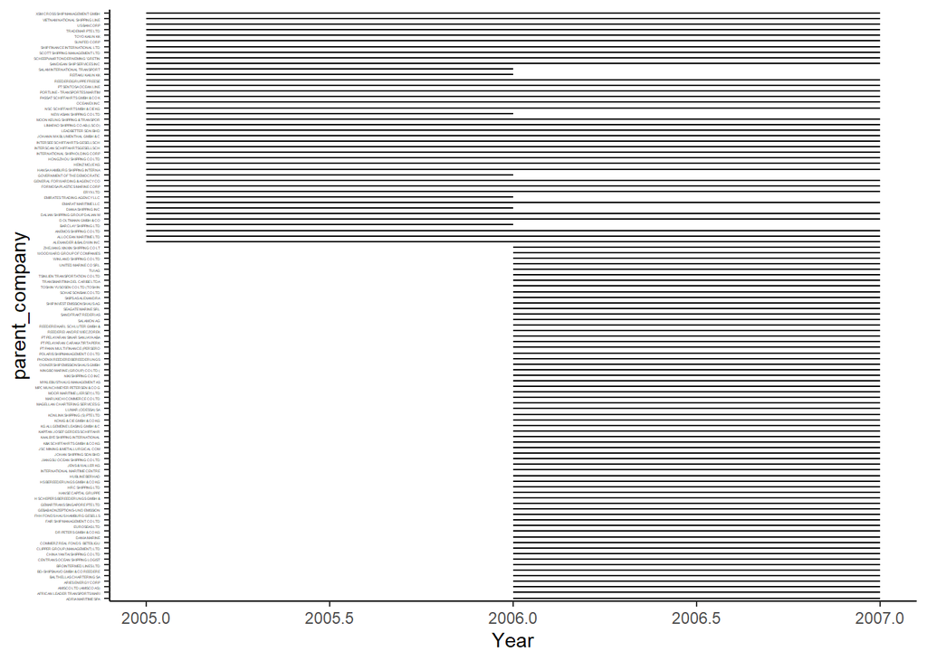

2006

A BOTTACCHI SA DE NAVEGACION

1990

1995

A P MOLLER

1990

2006

ALFRED C TOEPFER KG SCHIFFAHRT

1990

2006

ANDREW WEIR & CO LTD

1990

2006

APL LTD

1990

1997

BANK OF AMERICA NATIONAL TRUST

1990

1992

BANK OF SCOTLAND

1990

2000

BAUM & CO GMBH & CO KG

1990

2006

BEN LINE GROUP LTD (WM THOMSON

1990

1992

BERND BECKER KG

1990

2006

BUGSIER-REEDEREI-UND BERGUNGS-

1990

1996

BURMA NAVIGATION CORP

1990

1998

C& LINE CO LTD

1990

2006

CHENG LIE NAVIGATION CO LTD

1990

2006

CHINA OCEAN SHIPPING (GROUP) C

1990

2006

CHRISTIAN F AHRENKIEL GMBH & C

1990

2006

CITICORP

1990

1996

COLONIAL MARINE INDUSTRIES INC

1990

1994

COMPAGNIE GENERALE MARITIME E

1990

2002

COMPAGNIE MAROCAINE DE NAVIGAT

1990

2006

COMPANIA MARITIMA

1990

1991

COMPANIA SUDAMERICANA DE VAPO

1990

2006

COMPANIA TRASATLANTICA ESPANOL

1990

2004

CONTI REEDEREI

1990

2006

COSTAMARE SHIPPING CO SA

1990

2006

D’AMICO SOCIETA DI NAVIGAZIONE

1990

2006

DANSK INVESTERINGSFOND AF 1JUL

1990

1999

DELMAS

1990

2006

DMK LEASING A/S

1990

2006

DYVI AS

1990

1991

EGON OLDENDORFF OHG

1990

1997

ERIK THUN A/B

1990

1994

EVERGREEN MARINE CORP (TAIWAN)

1990

2006

F A VINNEN & CO (GMBH & CO KG)

1990

2006

F LAEISZ SCHIFFAHRTSGESELLSCHA

1990

2006

FAR-EAST TRANSPORT CO LTD

1990

1996

FARRELL LINES INC

1990

2000

FLENSBURGER SCHIFFSPARTEN-VERE

1990

2000

GATX CORP

1990

1992

GEORGE A CALLITSIS SUCCESSORS

1990

2006

GERD RITSCHER KG

1990

2006

GOVERNMENT OF THE UNITED STAT

1990

2006

GOVERNMENT OF THE PEOPLE’S RE

1990

2006

GOVERNMENT OF THE PEOPLE’S REP

1990

2006

GOVERNMENT OF THE REPUBLIC OF

1990

2006

H CLARKSON & CO LTD

1990

1994

HANJIN SHIPPING CO LTD

1990

2006

HAPAG-LLOYD AG

1990

2006

HDS AS

1990

1991

HERM DAUELSBERG GMBH & CO

1990

2006

HYUNDAI CORP

1990

2006

IMC SHIPPING CO PTE LTD (IMCSC

1990

1993

INDIA STEAMSHIP CO LTD

1990

1997

INTERORIENT NAVIGATION CO LTD

1990

2006

ISLAMAR SHIPMANAGEMENT CO LTD

1990

2006

JADROPLOV INTERNATIONAL MARITI

1990

2006

JAMES FISHER & SONS PLC

1990

1991

JARDINE SHIPPING LTD

1990

2006

JOHN SWIRE & SONS LTD

1990

2006

JOHN T ESSBERGER GMBH & CO KG

1990

2006

JOHS THODE GMBH & CO KG

1990

2006

KAMBARA KISEN CO LTD

1990

1999

KAWASAKI KISEN KAISHA LTD (KA

1990

2006

KDB CAPITAL CO LTD

1990

2006

KG PROJEX-SCHIFFAHRTS GMBH & C

1990

2006

KHATIB TRADING CO

1990

1996

KNUTSEN OAS SHIPPING AS

1990

2001

KOREA MARINE TRANSPORT CO LTD

1990

2006

LEONHARDT & BLUMBERG SCHIFFA

1990

2006

LLOYDS TSB GROUP PLC

1990

2006

LOADSTAR SHIPPING CO INC

1990

1991

MALAYSIA SHIPPING CORP SDN BHD

1990

2006

MARISCOS HYBUR SA

1990

1997

MARLOW NAVIGATION CO LTD

1990

2006

MARUBA SCA EMPRESA DE NAVEGAC

1990

2006

MARUBENI CORP

1990

2001

MATSON NAVIGATION CO INC

1990

2004

MEDITERRANEAN SHIPPING CO SA

1990

2006

MISC BERHAD

1990

2003

MITSUI OSK LINES LTD (MOL)

1990

2006

MIZUHO SANGYO CO LTD

1990

2006

MUTUALISTA ACOREANA DE TRANSPO

1990

2002

NANTAI LINE CO LTD

1990

1998

NAVIERA PINILLOS SA

1990

1998

NEGROS NAVIGATION CO INC

1990

2006

NEPTUNE ORIENT LINES LTD (NOL)

1990

2006

NIPPON KAIUN KK (NIPPON SHIPP

1990

2000

NIPPON MARINE CO LTD (NIPPON

1990

2006

NIPPON YUSEN KAISHA (NYK LINE)

1990

2006

NITTA KISEN KAISHA LTD

1990

2006

NORSE MANAGEMENT CO (PTE) LTD

1990

2006

NSB NIEDERELBE SCHIFFAHRTSGES

1990

2006

NV CMB SA

1990

2006

OFER BROTHERS (HOLDINGS) LTD

1990

2006

OK SHIPPING PTE LTD

1990

1992

OLDENBURG-PORTUGIESISCHE DAM

1990

1997

ORIENT EXPRESS LINES INC

1990

2006

ORIENT OVERSEAS INTERNATIONAL

1990

2006

OSAKA ASAHI KAIUN KK (OSAKA A

1990

2006

PACIFIC INTERNATIONAL LINES (P

1990

2006

PAN CONTINENTAL SHIPPING CO LT

1990

2006

PETER DOEHLE SCHIFFAHRTS-KG

1990

2006

POLISH OCEAN LINES (POLSKIE L

1990

1992

PT DJAKARTA LLOYD (PERSERO)

1990

2006

PT JAYAKUSUMA PERDANA LINES

1990

2006

PT PERUSAHAAN PELAYARAN ’SAMU

1990

2006

PT PERUSAHAAN PELAYARAN SAMUDE

1990

1994

PT TANTO INTIM LINE

1990

2006

PT TEMPURAN EMAS TBK

1990

2006

RCL SHIPMANAGEMENT PTE LTD

1990

1992

REA SHIPPING AGENCY CO SA

1990

1991

REEDEREI ‘NORD’ KLAUS E OLDEND

1990

2006

REEDEREI CLAUS-PETER OFFEN GMB

1990

2006

REEDEREI GEBR WINTER GMBH & CO

1990

2006

REEDEREI H - P WEGENER

1990

2006

REEDEREI HERMANN WULFF

1990

2006

REEFER & GENERAL SHIP-MANAGEME

1990

1998

REGIONAL CONTAINER LINES PUBLI

1990

2006

RICKMERS REEDEREI GMBH & CIE K

1990

2006

ROYAL P&O NEDLLOYD NV (KONINKL

1990

2006

RUDOLF A OETKER

1990

2006

SCHIFFAHRTSGESELLSCHAFT OLTMA

1990

2006

SCHIFFAHRTSKONTOR RENDSBURG GM

1990

2006

SEA CONTAINERS LTD

1990

1995

SEKIHYO LINE LTD

1990

1992

SEMBCORP MARINE LTD

1990

1996

SENO KISEN KK (SENO KISEN CO L

1990

1998

SETOUCHI MARINE CO LTD

1990

1991

SHANGHAI JINJIANG SHIPPING COR

1990

1991

SHINKO MARITIME CO LTD

1990

2003

SHOEI KISEN KAISHA LTD

1990

2006

SHUNZAN KAIUN KK (SHUNZAN KAI

1990

2006

SINOTRANS SHIPPING LTD (HONG K

1990

2002

STX PAN OCEAN CO LTD

1990

2006

SYARIKAT PERKAPALAN KRIS SDN

1990

2006

TEEKAY SHIPPING (CANADA) LTD

1990

1993

THE PENINSULAR AND ORIENTAL ST

1990

2004

THE SCHULTE GROUP

1990

2006

THIEN & HEYENGA BEREEDERUNGS-

1990

2006

TOKEI KAIUN KK

1990

2006

TRANSINSULAR -TRANSPORTES MARI

1990

1996

UNICORN SHIPPING PTY LTD

1990

2001

UNIQUE SHIPPING (HK) LTD

1990

2004

UNITED ARAB SHIPPING CO (UASC)

1990

2006

UNIVAN SHIP MANAGEMENT LTD

1990

1993

V SHIPS GROUP

1990

2002

VERTOM SCHEEPVAART EN HANDELS

1990

1991

VROON BV

1990

2006

WAH KWONG SHIPPING AGENCY CO L

1990

2006

WALLEM GROUP LTD

1990

1996

WALTHER MOLLER & CO

1990

2006

WILH WILHELMSEN ASA (WILSHIP)

1990

1991

WILMINGTON TRUST CO, AS TRUSTE

1990

2006

WING TAK SHIPPING AGENCY LTD

1990

2006

YANGMING MARINE TRANSPORT CORP

1990

2006

YANO KAIUN CO LTD

1990

2006

YONG LONG STEAMSHIP CO LTD

1990

1991

ZIM INTEGRATED SHIPPING SERVIC

1990

2006

NA

1990

2006

GOVERNMENT OF THE REPUBLIC OF

1991

2006

HAI SUN HUP CO (PTE) LTD

1991

2004

MITSUI & CO LTD

1991

1991

NISSEN KAIUN CO LTD (NISSEN KA

1991

2006

OAK MARITIME (CANADA) INC

1991

1992

TEH TUNG STEAMSHIP CO LTD

1991

1991

ABBEY NATIONAL PLC

1992

1997

ACTINOR SHIPPING ASA

1992

2002

BALTIC SHIPPING CO

1992

1996

BLACK SEA SHIPPING CO (CHERNO

1992

1999

BUSAN SHIPPING CO LTD

1992

1994

CABOTAGE VENEZOLANO ‘CABOVEN’

1992

1992

CHINA MERCHANTS STEAM NAVIGATI

1992

1994

CHIQUITA BRANDS INTERNATIONAL

1992

2006

COLUMBIA SHIPMANAGEMENT LTD

1992

2006

COMPANIA ISCOMAR SA

1992

1992

CONTENEMAR SA

1992

2006

DIETRICH TAMKE KG

1992

2006

ECHO HILL LTD

1992

1998

ERNST RUSS GMBH & CO KG

1992

2006

FAR-EASTERN SHIPPING CO (FESC

1992

2006

FUKUSEI SANGYO KK

1992

2006

GOLDENPORT SHIPMANAGEMENT LTD

1992

2006

GOVERNMENT OF ROMANIA

1992

1992

HANJIN TRANSPORTATION CO LTD

1992

2006

JOINT-STOCK CO NORTHERN RIVER

1992

1992

JOINT-STOCK VOLGA SHIPPING CO

1992

1992

JS NORTH-WESTERN SHIPPING CO

1992

1992

KAMBANG HOLDING LTD

1992

1992

KYOWA KISEN KK (KYOWA STEAMSH

1992

1997

LATVIAN SHIPPING CO (LATVIJAS

1992

1992

LUND, MOHR & GIAEVER-ENGER AS

1992

1996

MEDITERRANEAN SHIPPING CO SRL

1992

1992

NATIONAL MARINE SERVICES CO

1992

1996

NISSHIN SHIPPING CO LTD (NISS

1992

2001

OAO ‘SOVCOMFLOT’

1992

2006

OOST ATLANTIC LIJN BV

1992

2001

OSKAR WEHR KG (GMBH & CO)

1992

2006

PARAKOU SHIPPING LTD

1992

2002

RIO GRANDE CO LTD

1992

1992

ROHDEN BEREEDERUNG GMBH & CO K

1992

2006

SEATRANS SHIPPING SARL

1992

2006

SECIL MARITIMA UEE

1992

2001

THE ICELAND STEAMSHIP CO LTD (

1992

2006

TRANSPORTES NAVIEROS ECUATORIA

1992

1996

‘C.N.M. ROMLINE’ SHIPPING CO.

1993

1998

AKI KAIUN CO LTD (AKI KAIUN KK

1993

2006

DANAOS SHIPPING CO LTD

1993

2006

GUANGDONG PROVINCE, HONG KONG

1993

1997

HANSE BEREEDERUNGS GMBH

1993

2006

IRAN MARINE SERVICES CO

1993

2006

IRISH CONTINENTAL GROUP PLC

1993

1993

JAYA HOLDINGS LTD

1993

2005

JOINT STOCK NORTHERN SHIPPING

1993

2005

KING OCEAN SERVICES DE VENEZUE

1993

2006

KOBE SHIPPING CO LTD

1993

2006

PAN NAUTIC SA

1993

1996

SCHLUSSEL REEDEREI KG (GMBH &

1993

2006

SVITZER AS

1993

1996

THE HONGKONG SALVAGE & TOWAGE

1993

2001

WAN HAI LINES LTD

1993

2006

ANGLO-EASTERN SHIP MANAGEMENT

1994

2001

CENTRAL SHIPPING CO. INC.

1994

1999

CROWLEY MARITIME CORP

1994

1998

D EFTHYMIOU SHIPPING SA

1994

1994

DORIS MARITIME SERVICES SA

1994

2006

ERNST KOMROWSKI REEDEREI KG (G

1994

2006

FLEET NATIONAL BANK OF CONNECT

1994

2002

FLOTA MERCANTE GRANCOLOMBIANA

1994

1996

FRIEDHELM DEDE KG

1994

2006

FUH FUNG NAVIGATION AGENCY LTD

1994

1996

HERMANN BUSS GMBH & CIE

1994

2006

KASIF KALKAVAN VE ORTAKLARI K

1994

2006

KIEPE-SCHEPERS KG SCHIFFAHRT

1994

2006

KLINGENBERG BEREEDERUNGS UND

1994

2005

NAM SUNG SHIPPING CO LTD

1994

2006

NEW WORLD SHIPPING CO NV

1994

2002

PROJECT SHIPPING INC

1994

1995

SCHIFFAHRTSKONTOR TOM WORDEN G

1994

2006

SEAFARERS SHIPPING INC

1994

2006

STARLADY MARINE LTD

1994

2002

STOLT-NIELSEN TRANSPORTATION G

1994

1997

TARGET MARINE SA

1994

2006

TOYO SANGYO CO LTD (TOYO SANGY

1994

2006

TRAMP SL

1994

2006

TSAKOS SHIPPING & TRADING SA

1994

2006

UNITAS SCHIFFAHRTSGES MBH

1994

2006

UNITED THAI SHIPPING CORP LTD

1994

2006

WAGENBORG SHIPPING BV

1994

2006

YAMAMOTO KAIUN KK

1994

2006

ZHEJIANG FUCHUEN SHIPPING & E

1994

2004

DIORYX MARITIME CORP

1995

2006

DOLE FOOD CO

1995

2006

DT-BEREEDERUNGS GMBH & CO. KG

1995

2006

EASTERN STAR SHIPPING CO LTD

1995

1995

ESMERALDA SCHIFFAHRTS- VERWALT

1995

2006

FAIRWEATHER STEAMSHIP CO LTD

1995

2002

FAR EAST ENTERPRISING CO (HK)

1995

2005

FLYING LEAF SHIPPING LTD

1995

2006

GERD BARTELS (REEDEREI BARTELS

1995

2006

GOVERNMENT OF THE KINGDOM OF D

1995

2006

HARRY BROHAN

1995

2006

INTERSHIP NAVIGATION CO LTD

1995

1996

KAPITAN MANFRED DRAXL SCHIFFAH

1995

2006

LORENZO SHIPPING CORP

1995

2006

OCEANIC MARITIME LTD

1995

2006

OKOUCHI KAIUN KK (OKOCHI KAIUN

1995

2006

REEDEREI RUDOLF SCHEPERS KG

1995

2006

REEDEREI SPECK GBR

1995

1996

RICHFIELD MARINE AGENCIES (S)

1995

2004

SHIKISHIMA KISEN KK

1995

2006

SHINKO MARINE INDUSTRIES LTD

1995

2006

SHINWA KAIUN KK (SHINWA KAIUN

1995

1996

STAVROS DAIFAS MARINE ENTERPRI

1995

2000

SUNFORD SHIPPING LTD.

1995

2006

TANKER PACIFIC MANAGEMENT (SI

1995

1998

THE NATIONAL SHIPPING COMPANY

1995

2002

ALPHA SHIP GMBH

1996

2006

BOYANG SHIPPING CO LTD

1996

1998

BRINK & WOLFFEL

1996

2006

CARL F PETERS (GMBH & CO)

1996

2004

FUYO KAIUN SHIPMANAGEMENT CORP

1996

2005

HAN IL LEASING CO LTD

1996

2003

HARTMANN SCHIFFAHRTS GMBH & CO

1996

2006

LINE FAST PTE LTD

1996

1997

NAGASHIKI SHIPPING CO LTD (NAG

1996

2006

OKEANRYBFLOT JOINT STOCK CO (

1996

1996

RAINER FRED AUGUST DREVIN

1996

2006

REDERIET STENERSEN AS

1996

2000

REEDEREI HINSCH

1996

2006

RHEIN-, MAAS- UND SEE-SCHIFFAH

1996

2001

WILHELM TIETJEN BEFRACHTUNGSGE

1996

2004

ABOITIZ TRANSPORT SYSTEM CORP

1997

2004

B NAVI SPA

1997

2006

BALTIMAR A/S LTD

1997

2002

BROVIGS REDERI AS

1997

2003

BUDISUKMA SDN BHD

1997

2002

CHONG FUI SHIPPING & FORWARDIN

1997

1998

COMPAGNIE MARITIME MARFRET

1997

2006

CONTAL SHIPPING LTD

1997

2006

DANSK SUPERMARKED INVEST A/S

1997

2003

E NOMIKOS CORP

1997

2000

ENTERPRISES SHIPPING & TRADING

1997

2002

ERNST-AUGUST VON ALLWORDEN

1997

2006

FUKUJIN KISEN KK

1997

2006

FUYO KAIUN CO LTD

1997

2001

GOVERNMENT OF THE ISLAMIC REP

1997

2003

HAKKO MARINE & CORP

1997

1999

HALLA MARITIME CORP

1997

1997

IGNAZIO MESSINA & C SPA

1997

2006

IONIAN TANKERSHIPPING MARITIME

1997

1997

JUNGERHANS MARITIME SERVICES G

1997

2006

JUTHA MARITIME PUBLIC CO LTD

1997

2002

KEISHIN KAIUN CO LTD

1997

2006

KIRMAR DENIZCILIK VE TICARET A

1997

2002

KRISTIAN GERHARD JEBSEN SKIPSR

1997

1997

KUOK (SINGAPORE) LTD

1997

2006

MARCOMAR SHIPPING LINES CYPRUS

1997

1999

MARU SHIPPING CO INC

1997

2006

MC SHIPPING INC

1997

2006

MIDOCEAN (IOM) LTD

1997

1997

MITSUBISHI LOGISTICS CORP

1997

2003

MITSUHAMA KISEN KK

1997

2006

MIYAZAKI SANGYO KK

1997

2006

NEPTUNIA COMPANHIA DE NAVEGACA

1997

2006

ORIENT MARINE CO LTD (TOYO SEN

1997

1999

PACIFIC SHIP MANAGEMENT CO LTD

1997

1997

PAN-UNITED SHIPPING (PTE) LTD

1997

2006

PEARL DELTA SHIPPING CO LTD

1997

2006

POHL SHIPPING SCHIFFAHRTSGESEL

1997

2006

RASS SCHIFFAHRT GMBH & CO

1997

2006

REEDEREI BERND SIBUM GMBH & CO

1997

2006

REEDEREI EHLER

1997

2006

REEDEREI HEINO WINTER KG

1997

2006

REEDEREI JORG KOPPING

1997

2006

REEDEREI RUDOLF SCHEPERS GMBH

1997

2006

SETOUCHI ENTERPRISE CO LTD

1997

2006

SOCIETE GENERALE SA

1997

2006

SOKI KISEN KK

1997

2006

STAMCO SHIP MANAGEMENT CO LTD

1997

1998

TACHIBANAYA CO LTD (KK TACHIBA

1997

2004

TAIYO KAIUN KK

1997

2006

WILFRIED RAMBOW KG

1997

2006

ALCYON SHIPPING CO LTD

1998

1998

BRISE SCHIFFAHRTS GMBH

1998

2006

CENTRAL MARINE KK (CENTRAL MA

1998

2006

CHINA NATIONAL FOREIGN TRADE

1998

2006

CHIOS MARITIME SA

1998

2006

CONTAZ MARITIME TRANSPORT & TR

1998

2006

EAGLE MARITIME CO LTD

1998

2006

GEFONZO BV

1998

2006

GERD KOPPELMANN

1998

2006

GLORY SHIP MANAGEMENT PTE LTD

1998

1998

HENRY BREUER KG

1998

2006

HILL SAMUEL GROUP LTD

1998

2006

HINTERLAND CHARTERING SA

1998

1998

HYUNDAI INTERNATIONAL MERCHANT

1998

2006

INTEROCEAN SHIPPING CO LTD

1998

2006

ISLAMIC REPUBLIC OF IRAN SHIPP

1998

2006

J P SAMARTZIS MARITIME ENTERP

1998

2006

JINYU SHIPPING CO LTD (JINYU K

1998

2006

JURGEN OHLE

1998

2006

KOTOKU KAIUN KK (KOTOKU KAIUN

1998

2006

NATIONAL AUSTRALIA BANK LTD

1998

2006

OCEANBULK MARITIME SA

1998

2002

ODVAR OLSEN

1998

2001

PETRONAS (PETROLEUM NASIONAL B

1998

2006

PRIMA SHIPMANAGEMENT SDN BHD

1998

1999

QUADRANT BEREEDERUNGS GMBH & C

1998

2005

REEDEREI HANS HEINRICH KG

1998

2006

REEDEREI THOMAS SCHULTE GMBH &

1998

2006

SAMSKIP HF

1998

2006

SIGMA MARINE LTD

1998

1998

SIMATECH SHIPPING & FORWARDING

1998

2006

SINGA STAR PTE LTD

1998

2006

SOJITZ CORP

1998

2006

STENA AB

1998

2000

STRAND SHIPPING A/S

1998

2004

TAGASHIRA KAIUN CO LTD

1998

2006

TODA KISEN KK

1998

2006

TRANSMAN SHIPPING ENTERPRISES

1998

2006

VERMILION OVERSEAS MANAGEMENT

1998

2006

ALON MARITIME CORP

1999

1999

AMASUS SHIPPING BV

1999

1999

ARKAS GROUP OF COMPANIES

1999

2006

BAYRAKTAR GEMI ISLETMECILIGI

1999

2006

BELUGA SHIPPING GMBH

1999

2006

BERNUTH AGENCIES INC

1999

2006

CHINA SHIPPING (GROUP) CO

1999

2006

DONG JIN SHIPPING CO LTD

1999

2006

EHIME KISEN KK

1999

2006

EURASIA INTERNATIONAL (SINGAPO

1999

1999

GOVERNMENT OF THE SOCIALIST R

1999

2006

GOVERNMENT OF THE STATE OF QAT

1999

2006

GRUPO BOLUDA

1999

2006

HABRO HOLDING APS

1999

2006

HAKUSHIN KISEN CO LTD (HAKUSH

1999

2006

HAN SUNG SHIPPING CO LTD

1999

2004

INVESTERINGSGRUPPEN DANMARK A/

1999

2006

JOINT STOCK CO. ‘PERSEY’

1999

2006

JUHLKE SCHIFFAHRTS GMBH

1999

2006

KIN HING SHIPPING & ENTERPRISE

1999

2006

KREY SCHIFFAHRTS GMBH & CO KG

1999

2005

LOMAR SHIPPING LTD

1999

2004

LORENTZ STORESUND & SONNER

1999

1999

M FARUK URKMEZ GROUP OF COMPAN

1999

2003

MARUSAN KAIUN KK

1999

2006

MASUMOTO SHIPPING CO LTD

1999

2006

O T TONNEVOLD AS

1999

2006

PT PELAYARAN LAUT BARU

1999

2006

REEDEREI M LAUTERJUNG GMBH

1999

2006

REEDEREI THEKLA SCHEPERS GMBH

1999

2006

RUDOLF SCHONING GMBH

1999

2006

SINGAPORE SOVIET SHIPPING CO

1999

2000

SOJITZ MARINE & ENGINEERING CO

1999

2005

SPLIETHOFF’S BEVRACHTINGSKANTO

1999

2006

THENAMARIS (SHIPS MANAGEMENT)

1999

2000

TOKO UNYU KK

1999

2006

TOSOH LOGISTICS CORP (TOSOH B

1999

2006

TRANSESTE SCHIFFAHRT GMBH

1999

2005

WORLD MARINE CO LTD

1999

2006

YARDIMCI SHIPPING GROUP

1999

2006

ARKLOW SHIPPING LTD

2000

2004

BBC - BURGER BEREEDERUNGS CONT

2000

2000

BRIESE SCHIFFAHRTS GMBH & CO K

2000

2006

BULLS TANKREDERI A/S

2000

2006

CARDIFF MARINE INC

2000

2002

CMA CGM HOLDING

2000

2006

COSMOSHIP MANAGEMENT SA

2000

2006

DEHAI MARINE SHIPPING (SINGAPO

2000

2004

ESSCO (HELLAS) LTD

2000

2002

EUROBULK LTD

2000

2005

FORTUNE GLORY PTE LTD

2000

2006

HALIFAX PLC

2000

2006

HALIM MAZMIN GROUP

2000

2006

HANSA SHIPPING GMBH & CO KG

2000

2005

HOLWERDA SHIPMANAGEMENT BV

2000

2006

HORIZON LINES INC

2000

2006

KOTANI SHIPMANAGEMENT LTD

2000

2000

L. J. GOTZ K.G.

2000

2006

MEIHO KAIUN KK

2000

2006

MIKKAL MYKLEBUSTHAUG REDERI AS

2000

2006

NATIONAL NAVIGATION CO

2000

2006

NIMMRICH & PRAHM BEREEDERUNG G

2000

2001

NORDDEUTSCHE REEDEREI H SCHULD

2000

2000

PT PELAYARAN NUSANTARA SALAM

2000

2006

REEDEREI HORST ZEPPENFELD GMBH

2000

2006

REEDEREI STEFAN PATJENS GMBH &

2000

2006

SANKYO COMMERCIAL CO LTD (SAN

2000

2006

SINOKOR MERCHANT MARINE CO LTD

2000

2006

THOME & CO PTE LTD

2000

2002

TOKAI SHIPPING CO LTD (TOKAI

2000

2006

TYSON MARINE PTE LTD

2000

2003

VAN YU TRADING CO LTD

2000

2006

ASP PACIFIC HOLDINGS PTY LTD

2001

2006

CAPITAL BANK PLC

2001

2006

CIEL SHIPMANAGEMENT SA

2001

2002

DENAK DEPOCULUK VE NAKLIYECILI

2001

2005

EITZEN GROUP (CAMILLO EITZEN &

2001

2001

JR SHIPPING BV

2001

2006

KEIYO KISEN KK

2001

2006

MARTIME - GESELLSCHAFT FUR MAR

2001

2006

MURAKAMI HIDE SHIPBUILDING CO

2001

2006

NORDCAPITAL HOLDING GMBH & CIE

2001

2006

NORDDEUTSCHE VERMOGENSANLAGE G

2001

2006

PANCON SHIPPING & MARINE SERVI

2001

2006

PT PERUSAHAAN PELAYRAN SAMUDER

2001

2004

REEDEREI ALNWICK HARMSTORF & C

2001

2006

REEDEREI HEINZ-GEORG VOGE KG

2001

2006

REEDEREI HEINZ CORLEIS KG

2001

2006

RETTIG GROUP LTD BORE (OY RETT

2001

2004

SEALIFT INC

2001

2006

STATE ENTERPRISE MARIUPOL SEA

2001

2003

STORESLETTEN REDERI AS

2001

2002

TECHNOMAR SHIPPING INC

2001

2006

THE ROYAL BANK OF SCOTLAND GRO

2001

2006

TIANJIN-INCHON INTERNATIONAL

2001

2001

ZODIAC MARITIME AGENCIES LTD

2001

2006

ADANI SHIPPING (CHINA) CO LTD

2002

2006

ATLANTIC HORIZON GROUP

2002

2006

CARSTEN REHDER SCHIFFSMAKLER U

2002

2006

COMPAGNIE DE NAVIGATION DU DET

2002

2006

CONTAINERSHIPS LTD OY (CONTAIN

2002

2006

CYPRUS MARITIME CO LTD

2002

2002

DOUN KISEN KK

2002

2006

EFSHIPPING CO SA PANAMA

2002

2002

EICKE SCHIFFAHRTS KG

2002

2006

MITSUI WAREHOUSE CO LTD (MITS

2002

2006

RED RIVER CARRIERS INC

2002

2006

RIMORCHIATORI RIUNITI SPA

2002

2004

SUISSE-ATLANTIQUE SOCIETE DE

2002

2006

TEO SHIPPING CORP

2002

2006

TONICHI SANGYO KK

2002

2004

USUI KAIUN KK

2002

2004

A&L CF DECEMBER (1) LTD

2003

2006

ALLOCEAN LTD

2003

2006

ALUNITED MARITIME BUSINESS (PV

2003

2006

ARCTIC SHIPPING CO (OAO SK A

2003

2006

BARCLAYS BANK PLC

2003

2006

BBG-BREMER BEREEDERUNGSGESELLS

2003

2006

BERNHARD CRAMER SCHIFFAHRTS- U

2003

2006

BESLEASING MOBILIARIA-SOCIEDAD

2003

2006

COMMERCIAL FLEET OF DONBASS LT

2003

2006

COSTA CONTAINER LINES SPA

2003

2006

CP SHIPS LTD

2003

2006

CYPRUS SEA LINES SA

2003

2003

DALEX SHIPPING CO SA

2003

2006

ER SCHIFFAHRT GMBH & CIE KG

2003

2003

ERRIA A/S

2003

2006

FLEET MANAGEMENT LTD

2003

2003

FOROOHARI SCHIFFAHRTS KG (REED

2003

2006

FUJIAN XINAN SHIPPING CO LTD

2003

2006

GHS GLOBAL HANSEATIC SHIPPING

2003

2005

HANSA TREUHAND SCHIFFSBETEILIG

2003

2006

HANSEATIC LLOYD AG

2003

2006

HSBC BANK PLC

2003

2006

INTER SHIPPING CO LTD

2003

2006

JSM-SHIPPING GMBH & CO KG

2003

2006

KIKU KAIYO KOSAN KK (KIKU OCE

2003

2006

KIRAN GROUP OF SHIPPING COMPAN

2003

2003

KRISTEN MARINE SA

2003

2004

MARCONSULT SCHIFFAHRT GMBH & C

2003

2006

MARYVILLE MARITIME INC

2003

2003

NARU SHIPPING & MANAGEMENT CO

2003

2006

NAVALMAR (UK) LTD

2003

2006

NEPTUNE SHIPPING AGENCY LTD

2003

2006

NIPPON STEEL SHIPPING CO LTD

2003

2005

ORIENT INTERNATIONAL (HOLDING)

2003

2006

PERKAPALAN DAI ZHUN SDN BHD (

2003

2006

PT PELAYARAN TIRTAMAS EXPRESS

2003

2005

PT TARUNA CIPTA KENCANA

2003

2006

PUSAKA LAUT PTE LTD

2003

2004

ROSWELL NAVIGATION CORP

2003

2006

SCHIFFAHRTSGESELLSCHAFT WOLFGA

2003

2006

SEABON HOLDING CORP

2003

2006

SEASPAN INTERNATIONAL LTD

2003

2006

SETRAMAR NAVIGAZIONE SPA

2003

2005

SETSUYO KISEN CO LTD

2003

2006

SHIH WEI NAVIGATION CO LTD

2003

2006

SHINHAN LEASING CO LTD

2003

2006

STATE STREET BANK & TRUST CO

2003

2005

STROFCOM SHIPPING CO LTD

2003

2006

THE ANGLO-EASTERN GROUP

2003

2006

VEGA-REEDEREI FRIEDRICH DAUBER

2003

2006

W BOCKSTIEGEL REEDEREI GMBH &

2003

2006

WINCO MARITIME LTD

2003

2004

ARADOS SHIPPING CO SRL

2004

2006

CAPABILITY BV

2004

2006

CEYLINE SHIPPING LTD

2004

2006

DEKAMAR SHIPPING & TRADING CO

2004

2006

DELPHIS NV

2004

2005

E-SHIPS INC

2004

2004

FARGLORY SHIPMANAGEMENT PTE LT

2004

2006

FORESIGHT LTD

2004

2004

GEBRUDER AHRENS KG

2004

2006

KANG LONG SHIPPING CO LTD

2004

2006

NORDSTRAND MARITIME & TRADING

2004

2006

PLATINUM CONTAINER LINES CO LT

2004

2006

PT PELAYARAN MERATUS (MERATUS

2004

2006

REEDEREI NAVYLLOYD AG

2004

2006

SCHOELLER HOLDINGS LTD

2004

2006

SEA CONSORTIUM PTE LTD

2004

2006

VAPORES SUARDIAZ SA

2004

2004

YONG HAI AGENCIES

2004

2006

ALEXANDER & BALDWIN INC

2005

2006

ALLOCEAN MARITIME LTD

2005

2006

ANEMOS SHIPPING CO LTD

2005

2006

BARCLAY SHIPPING LTD

2005

2005

D OLTMANN GMBH & CO

2005

2006

DALIAN SHIPPING GROUP DALIAN M

2005

2006

DIANA SHIPPING INC

2005

2005

EMARAT MARITIME LLC

2005

2006

EMIRATES TRADING AGENCY LLC

2005

2005

ERYX LTD

2005

2006

FORMOSA PLASTICS MARINE CORP

2005

2006

GENERAL FORWARDING & AGENCY CO

2005

2006

GOVERNMENT OF THE DEMOCRATIC

2005

2005

HANSA HAMBURG SHIPPING INTERNA

2005

2006

HEINZ MOJE KG

2005

2006

HONGZHOU SHIPPING CO LTD

2005

2006

INTERNATIONAL SHIPHOLDING CORP

2005

2006

INTERSCAN SCHIFFAHRTSGESELLSCH

2005

2006

INTERSEE SCHIFFAHRTS-GESELLSCH

2005

2006

JOHANN M K BLUMENTHAL GMBH & C

2005

2006

LEADBETTER SDN BHD

2005

2006

LIMARKO SHIPPING CO AB (LSCO)

2005

2006

MOON KEUNG SHIPPING & TRANSPOR

2005

2006

NEW ASIAN SHIPPING CO LTD

2005

2005

NSC SCHIFFAHRTS MBH & CIE KG

2005

2006

OCEANEX INC

2005

2006

PASSAT SCHIFFAHRTS GMBH & CO K

2005

2006

PORTLINE - TRANSPORTES MARITIM

2005

2006

PT SENTOSA OCEAN LINE

2005

2006

REEDEREIGRUPPE FREESE

2005

2006

REITAKU KAIUN KK

2005

2005

SALAM INTERNATIONAL TRANSPORT

2005

2005

SANDIGAN SHIP SERVICES INC

2005

2006

SCHEEPVAARTONDERNEMING ’GRETIN

2005

2006

SCOTT SHIPPING MANAGEMENT LTD

2005

2006

SHIP FINANCE INTERNATIONAL LTD

2005

2006

SUNFED CORP

2005

2006

TOYO KAIUN KK

2005

2006

TRADEMAR PTE LTD

2005

2006

US BANCORP

2005

2006

VIETNAM NATIONAL SHIPPING LINE

2005

2006

XSM CROSS SHIP MANAGEMENT GMBH

2005

2006

ADRIA MARITIME SPA

2006

2006

AFRICAN LEADER TRANSPORTS MARI

2006

2006

AMISCO LTD (AMISCO AS)

2006

2006

ARIES ENERGY CORP

2006

2006

BALTHELLAS CHARTERING SA

2006

2006

BD-SHIPSNAVO GMBH & CO REEDERE

2006

2006

BROINTERMED LINES LTD

2006

2006

CENTRANS OCEAN SHIPPING LOGIST

2006

2006

CHINA YANTAI SHIPPING CO LTD

2006

2006

CLIPPER GROUP (MANAGEMENT) LTD

2006

2006

COMMERZ REAL FONDS BETEILIGU

2006

2006

DANIA MARINE

2006

2006

DR PETERS GMBH & CO KG

2006

2006

EUROSEAS LTD

2006

2006

FAIR SHIP MANAGEMENT CO LTD

2006

2006

FHH FONDS HAUS HAMBURG GESELLS

2006

2006

GEBAB KONZEPTIONS-UND EMISSION

2006

2006

GEMARTRANS SINGAPORE PTE LTD

2006

2006

H SCHEPERS BEREEDERUNGS GMBH &

2006

2006

HANSE CAPITAL GRUPPE

2006

2006

HRC SHIPPING LTD

2006

2006

HS BEREEDERUNGS GMBH & CO KG

2006

2006

HUBLINE BERHAD

2006

2006

INTERNATIONAL MARITIME CENTRE

2006

2006

JENS & WALLER KG

2006

2006

JIANGSU OCEAN SHIPPING CO LTD

2006

2006

JOHAN SHIPPING SDN BHD

2006

2006

JSC MINING & METALLURGICAL COM

2006

2006

K&K SCHIFFAHRTS GMBH & CO KG

2006

2006

KAALBYE SHIPPING INTERNATIONAL

2006

2006

KAPITAN JOSEF GERDES SCHIFFAHR

2006

2006

KG ALLGEMEINE LEASING GMBH & C

2006

2006

KONIG & CIE GMBH & CO KG

2006

2006

KONLINK SHIPPING (S) PTE LTD

2006

2006

LUMAR (ODESSA) SA

2006

2006

MAGELLAN CHARTERING SERVICES G

2006

2006

MARUKICHI COMMERCE CO LTD

2006

2006

MOOR MARITIME (JERSEY) LTD

2006

2006

MPC MUNCHMEYER PETERSEN & CO G

2006

2006

MYKLEBUSTHAUG MANAGEMENT AS

2006

2006

NIKI SHIPPING CO INC

2006

2006

NINGBO MARINE (GROUP) CO LTD (

2006

2006

OWNERSHIP EMISSIONSHAUS GMBH

2006

2006

PHOENIX REEDEREI BEREEDERUNGS

2006

2006

POLARIS SHIPMANAGEMENT CO LTD

2006

2006

PT PANN MULTI FINANCE (PERSERO

2006

2006

PT PELAYARAN CARAKA TIRTA PERK

2006

2006

PT PELAYARAN SINAR SANJAYA ABA

2006

2006

REEDEREI ANDRE WIECZOREK

2006

2006

REEDEREI KARL SCHLUTER GMBH &

2006

2006

SALAMON AG

2006

2006

SANDFRAKT REDERI AS

2006

2006

SEAGATE MARINE SRL

2006

2006

SHIP INVEST EMISSIONSHAUS AG

2006

2006

SKIPS AS ALEXANDRA

2006

2006

SOHAE SONBAK CO LTD

2006

2006

TOSHIN YUSOSEN CO LTD (TOSHIN

2006

2006

TRANSMARITIMA DEL CARIBE LTDA

2006

2006

TSINLIEN TRANSPORTATION CO LTD

2006

2006

TUI AG

2006

2006

UNITED MARINE CO SRL

2006

2006

WINLAND SHIPPING CO LTD

2006

2006

WOODWARD GROUP OF COMPANIES

2006

2006

ZHEJIANG XINXIN SHIPPING CO LT

2006

2006

### HB_data

#### Merger list

| …1 | operator_name | start | end | merging_firm | note |
| --- | --- | --- | --- | --- | --- |
| 2 | ANL | 2005 | 2022 | CMA-CGM | Subsidiary of CMA-CGM since 1998 |
| 3 | APL | 2005 | 2022 | CMA-CGM | Subsidiary of CMA-CGM since 2016 |
| 7 | CCNI | 2005 | 2015 | Maersk | NA |
| 9 | Cheng Lie | 2005 | 2006 | CMA-CGM | NA |
| 10 | China Shipping | 2005 | 2016 | COSCO | NA |
| 13 | CMA-CGM/MSC | 2005 | 2006 | CMA-CGM | NA |
| 15 | CSAV | 2005 | 2015 | Hapag-Lloyd | NA |
| 20 | Delmas | 2005 | 2016 | CMA-CGM | NA |
| 34 | Greater Bali-Hai | 2005 | 2014 | Swire | Subsidiary of Swire |
| 35 | Grupo TMM | 2005 | 2005 | Hapag-Lloyd | NA |
| 37 | Hamburg Sud | 2005 | 2022 | Maersk | NA |
| 46 | Intermarine | 2005 | 2010 | ZEAMARINE | General Cargo |
| 47 | IRISL | 2005 | 2010 | Hafez Darya Arya Shipping Lines | NA |
| 52 | KLINE | 2005 | 2018 | Ocean Network Express | NA |
| 57 | Lloyd Triestino | 2005 | 2006 | Evergreen | NA |
| 58 | Lufeng | 2005 | 2008 | Sinotrans | NA |
| 59 | Lykes | 2005 | 2005 | Hapag-Lloyd | NA |
| 67 | MOL | 2005 | 2018 | Ocean Network Express | NA |
| 69 | Nagato | 2005 | 2014 | Hyoki Kaiun | General Cargo |
| 71 | NEW ONTO SHIPPING | 2005 | 2010 | CCL | NA |
| 73 | Norasia | 2005 | 2006 | CSAV | NA |
| 74 | NYK | 2005 | 2018 | Ocean Network Express | NA |
| 77 | P. Continental | 2005 | 2007 | Pan Continental | NA |
| 83 | PONL | 2005 | 2006 | Maersk | NA |
| 87 | Rickmers | 2005 | 2019 | ZEAMARINE | General Cargo |
| 88 | Safmarine | 2005 | 2008 | Maersk | NA |
| 92 | Senator | 2005 | 2005 | Hanjin | NA |
| 112 | TSK | 2005 | 2010 | NYK | NA |
| 113 | UASC | 2005 | 2017 | Hapag-Lloyd | NA |
| 122 | S. S. Ferry/Orient Ferry | 2006 | 2007 | Suzhou Shimonoseki Ferry | Ferry |
| 128 | MacAndrews | 2007 | 2007 | CMA-CGM | NA |
| 137 | KL/MOL | 2008 | 2008 | Ocean Network Express | NA |
| 146 | Chongqing Marine | 2010 | 2011 | TAICANG CONTAINER LINES | NA |
| 151 | China Navigation | 2011 | 2011 | Swire | NA |
| 157 | Shanghai Puhai Shipping | 2011 | 2016 | COSCO | NA |
| 161 | SEACON/T.S. Lines | 2013 | 2013 | T.S. Lines | NA |
| 163 | Sealand Asia | 2014 | 2022 | Maersk | NA |
| 166 | APL/PIL | 2017 | 2017 | CMA-CGM | NA |

#### Overall Transition

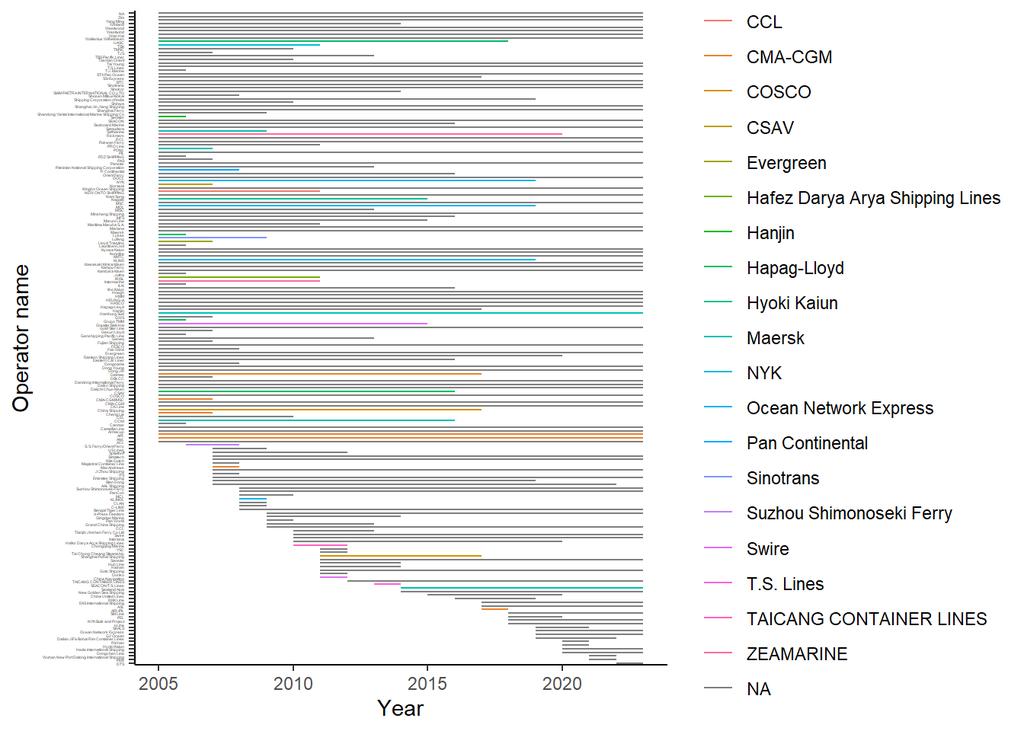

| …1 | operator_name | start | end | merging_firm | note | merging_firm_color |
| --- | --- | --- | --- | --- | --- | --- |
| 1 | ACL | 2005 | 2022 | NA | NA | ACL |
| 2 | ANL | 2005 | 2022 | CMA-CGM | Subsidiary of CMA-CGM since 1998 | CMA-CGM |
| 3 | APL | 2005 | 2022 | CMA-CGM | Subsidiary of CMA-CGM since 2016 | CMA-CGM |
| 4 | Armacup | 2005 | 2022 | NA | Ferry | Armacup |
| 5 | Camellia Line | 2005 | 2022 | NA | Ferry | Camellia Line |
| 6 | Canmar | 2005 | 2005 | NA | NA | Canmar |
| 7 | CCNI | 2005 | 2015 | Maersk | NA | Maersk |
| 8 | CEL | 2005 | 2009 | NA | NA | CEL |
| 9 | Cheng Lie | 2005 | 2006 | CMA-CGM | NA | CMA-CGM |
| 10 | China Shipping | 2005 | 2016 | COSCO | NA | COSCO |
| 11 | CK Line | 2005 | 2022 | NA | NA | CK Line |
| 12 | CMA-CGM | 2005 | 2022 | NA | NA | CMA-CGM |
| 13 | CMA-CGM/MSC | 2005 | 2006 | CMA-CGM | NA | CMA-CGM |
| 14 | COSCO | 2005 | 2022 | NA | NA | COSCO |
| 15 | CSAV | 2005 | 2015 | Hapag-Lloyd | NA | Hapag-Lloyd |
| 16 | Daiichi Chuo Kisen | 2005 | 2022 | NA | General Cargo | Daiichi Chuo Kisen |
| 17 | Daiko Shipping | 2005 | 2022 | NA | General Cargo | Daiko Shipping |
| 18 | Dandong International Ferry | 2005 | 2022 | NA | Ferry | Dandong International Ferry |
| 19 | DBLCC | 2005 | 2006 | NA | NA | DBLCC |
| 20 | Delmas | 2005 | 2016 | CMA-CGM | NA | CMA-CGM |
| 21 | Dong Jin | 2005 | 2022 | NA | NA | Dong Jin |
| 22 | Dong Young | 2005 | 2022 | NA | NA | Dong Young |
| 23 | Dongnama | 2005 | 2007 | NA | NA | Dongnama |
| 24 | Eastern Car Liner | 2005 | 2015 | NA | General Cargo | Eastern Car Liner |
| 25 | Eastern Shipping Lines | 2005 | 2019 | NA | NA | Eastern Shipping Lines |
| 26 | Evergreen | 2005 | 2022 | NA | NA | Evergreen |
| 27 | Fair Wind | 2005 | 2007 | NA | NA | Fair Wind |
| 28 | FESCO | 2005 | 2022 | NA | NA | FESCO |
| 29 | Fujian Shipping | 2005 | 2006 | NA | NA | Fujian Shipping |
| 30 | Geneq | 2005 | 2012 | NA | NA | Geneq |

[output cut: 153 more lines]